# Harshavardhan Aila UNT ID:11636549

# **Activity 2: Regular Expressions**

## Those who are not able to make it to the class are required to provide explanations for the code part provided in the tutorial by adding a text below the code cell.

### **Note**: your explanation must include how the code works and libraries used and why they are used.

### Students who are present in the class need to complete the activity and answer the question given at the end of tutorial.

## Regular Expressions

a language for specifying text search regular expression strings. This practical language is used in every computer language, word processor, and text processing tools like the Unix tools grep or Emacs. Formally, a regular expression is an algebraic notation for characterizing a set of strings. Regular expressions are particularly useful for searching in texts, when we have a pattern to search corpus for and a corpus of texts to search through. A regular expression search function will search through the corpus, returning all texts that match the pattern. The corpus can be a single document or a collection. For example, the Unix command-line tool grep takes a regular expression and returns every line of the input document that matches the expression.

Python includes a builtin module called `re` which provides regular expression matching operations (Click [here](https://docs.python.org/3/library/re.html) for the official module documentation). Once the module is imported into your code, you can use all of the available capabilities for performing pattern-based matching or searching using regular expressions.

```python
##code block-1
import re

def apply_regex(data, pattern):
  for text in data:
    if re.fullmatch(pattern, text):
      print(f"Test string {text} accepted.")
    else:
      print(f"Test string {text} failed!")
```

Let's write a simple regular expression for matching binary strings.

```python
##code block-2
# find binary strings
test_strings = ["0", "1", "dog", "hello, world", "123", "00", "10101010111"]
binary_pattern = r'[0-1]+'
apply_regex(test_strings, binary_pattern)
```

```
Test string 0 accepted.
Test string 1 accepted.
Test string dog failed!
Test string hello, world failed!
Test string 123 failed!
Test string 00 accepted.
Test string 10101010111 accepted.
```

In the code block - 2 first a set of test strings are defined to test a simple regular expression. The binary pattern is defined with r' ' to denote it's a regular expression.The format [0-1]+ is for the list of expressions that can be accepted for this case it would be numbers between 0 and 1.

Now, how about for matching 24-bit hexadecimal codes?

```python
##code block-3
test_strings = ["#F0F8FF", "#FFF", "#00FFFFF", "#2980BD", "#FAEBD7"]
hexcode_pattern = r'\#[0-9A-F]{5,6}'
apply_regex(test_strings, hexcode_pattern)
```

```
Test string #F0F8FF accepted.
Test string #FFF failed!
Test string #00FFFFF failed!
Test string #2980BD accepted.
Test string #FAEBD7 accepted.
```

The code block -3 implementation follows the same methodology, since the code is trying to match hexadecimal the test strings are defined as such. The pattern to match the required hexadecimal code would be starting with # and all numbers between 0 - 9 and the alphabets between A and F, the length of the expression would be between 5 and 6 characters

## Evaluating a `test_string` against a given `re_pattern`.

```python
##code block-4

re_pattern = r'(\([0-9]{3}\)\s)?\d{3}\.\d{3}\.\d{4}'
test_strings = ["00", "999-999-9999", "987.123.4567", "(111) 111-1111", "(111)111-1111", "989-1830", "241/131/103", "(182).1903.1021", "(101).101.1001"]

apply_regex(test_strings, re_pattern)
```

```
Test string 00 failed!
Test string 999-999-9999 failed!
Test string 987.123.4567 accepted.
Test string (111) 111-1111 failed!
Test string (111)111-1111 failed!
Test string 989-1830 failed!
Test string 241/131/103 failed!
Test string (182).1903.1021 failed!
Test string (101).101.1001 failed!
```

#### **Question 1**

*Modify the regular expression in the code block -4 to also accept strings that follow the format `xxx.xxx.xxxx` and `+1 xxx-xxx-xxxx` where `x` is a digit between 0 to 9?*

Note:Use different Code blocks for each teststring given in the task

# RegEx for xxx.xxx.xxxx format where x is a digit between 0 to 9:

```python
##your code here
re_pattern = r'(\([0-9]{3}\)\s)?\d{3}\.\d{3}\.\d{4}'
test_strings = ["00", "999-999-9999", "987.123.4567", "(111) 111-1111", "912.234.1234","(111)111-1111", "989-1830", "241/131/103", "(182).1903.1021", "945.123.1234","(101).101.1001"]

apply_regex(test_strings, re_pattern)
```

```
Test string 00 failed!
Test string 999-999-9999 failed!
Test string 987.123.4567 accepted.
Test string (111) 111-1111 failed!
Test string 912.234.1234 accepted.
Test string (111)111-1111 failed!
Test string 989-1830 failed!
Test string 241/131/103 failed!
Test string (182).1903.1021 failed!
Test string 945.123.1234 accepted.
Test string (101).101.1001 failed!
```

# RegEx for +1 xxx-xxx-xxxx format where x is a digit between 0 to 9:

```python
re_pattern3 = r'\+1\s[0-9]{3}-[0-9]{3}-[0-9]{4}'
test_strings3 = ["00", "+1 940-843-0538","999-999-9999", "+1 989-789-5678","(111) 111-1111", "+1 987-987-9876", "(111)111-1111", "989-1830", "241/131/103", "(182).1903.1021", "(101).101.1001"]

apply_regex(test_strings3, re_pattern3)
```

```
Test string 00 failed!
Test string +1 940-843-0538 accepted.
Test string 999-999-9999 failed!
Test string +1 989-789-5678 accepted.
Test string (111) 111-1111 failed!
Test string +1 987-987-9876 accepted.
Test string (111)111-1111 failed!
Test string 989-1830 failed!
Test string 241/131/103 failed!
Test string (182).1903.1021 failed!
Test string (101).101.1001 failed!
```

## Basic Regular Expression Patterns

The simplest kind of regular expression is a sequence of simple characters; putting characters in sequence is called concatenation. To search for woodchuck, we type /woodchuck/. The expression /Buttercup/ matches any string containing the substring Buttercup; grep with that expression would return the line I’m called little Buttercup.

Regular expressions are case sensitive; lower case /s/ is distinct from upper case /S/ (/s/ matches a lower case s but not an upper case S). This means that the pattern /woodchucks/ will not match the string Woodchucks. We can solve this problem with the use of the square braces [ and ]. The string of characters inside the braces specifies a disjunction of characters to match

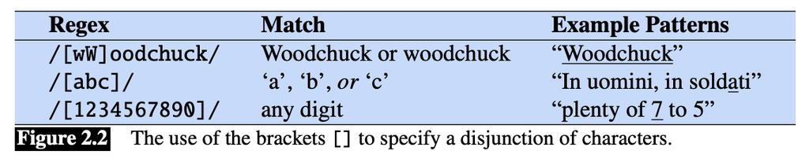

The regular expression /[1234567890]/ specifies any single digit. While such classes of characters as digits or letters are important building blocks in expressions, they can get awkward (e.g., it’s inconvenient to specify /[ABCDEFGHIJKLMNOPQRSTUVWXYZ]/ to mean “any capital letter”). In cases where there is a well-defined sequence associated with a set of characters, the brackets can be used with the dash (-) to specify any one character in a range. The pattern /[2-5]/ specifies any one of the characters 2, 3, 4, or 5. The pattern /[b-g]/ specifies one of the characters b, c, d, e, f, or g.

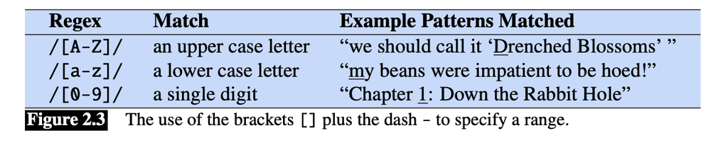

`re.findall()` finds all matches of the pattern in the text under consideration. The output is a list of strings that matched.

```python
text = """Here is the First Paragraph and this is the First Sentence. here is the Second Sentence. now is the Third Sentence. this is the Fourth Sentence of the first paragaraph. this paragraph is ending now with a Fifth Sentence.
Now, it is the Second Paragraph and its First Sentence. here is the Second Sentence."""
```

```python
re_pattern1 = r'[A-Z][a-z]+ [A-Z][a-z]+'
print(re.findall(re_pattern1, text))
```

```
['First Paragraph', 'First Sentence', 'Second Sentence', 'Third Sentence', 'Fourth Sentence', 'Fifth Sentence', 'Second Paragraph', 'First Sentence', 'Second Sentence']
```

"Now, let's find occurrences by using regular expressions."

```python
##code block-4
import re
text = "cats are cute and dogs are loyal"
pattern = r"\bc[a-z]*|\bd[a-z]*\b"
re.findall(pattern, text)
```

```
['cats', 'cute', 'dogs']
```

"In the provided code block -4, the given regular expression pattern attempts to identify words that begin with the letters 'c' and 'd'.". \b before c[a-z] *ensures we match full words starting with c \b after d[a-z]* ensures we match full words starting with d

#### **Question 2.**

## Now try to match words ending in 'ing' or 'ly' by using the given statement

```python
##your code here
import re
text = "amazing view lovely painting writing"
pattern = r"\b\w+(?:ing|ly)\b"
matches = re.findall(pattern, text)
print(matches)
```

```
['amazing', 'lovely', 'painting', 'writing']
```

## **Using regular expressions based pattern matching on real world text**

For the purposes of demonstration, here's a dummy paragraph of text. A few observations here:

- The text has multiple paragraphs with each paragraph having more than one sentence.
- Some of the words are capitalized (first letter is in uppercase followed by lowercase letters).

```python
##code block-5
text = """Here is the First Paragraph and this is the First Sentence. here is the Second Sentence. now is the Third Sentence. this is the Fourth Sentence of the first paragaraph. this paragraph is ending now with a Fifth Sentence.
Now, it is the Second Paragraph and its First Sentence. here is the Second Sentence. now is the Third Sentence. this is the Fourth Sentence of the second paragraph. this paragraph is ending now with a Fifth Sentence.
Finally, this is the Third Paragraph and is the First Sentence of this paragraph. here is the Second Sentence. now is the Third Sentence. this is the Fourth Sentence of the third paragaraph. this paragraph is ending now with a Fifth Sentence.
4th paragraph is not going to be detected by either of the regex patterns below.
"""

print(text)
```

```
Here is the First Paragraph and this is the First Sentence. here is the Second Sentence. now is the Third Sentence. this is the Fourth Sentence of the first paragaraph. this paragraph is ending now with a Fifth Sentence.
Now, it is the Second Paragraph and its First Sentence. here is the Second Sentence. now is the Third Sentence. this is the Fourth Sentence of the second paragraph. this paragraph is ending now with a Fifth Sentence.
Finally, this is the Third Paragraph and is the First Sentence of this paragraph. here is the Second Sentence. now is the Third Sentence. this is the Fourth Sentence of the third paragaraph. this paragraph is ending now with a Fifth Sentence.
4th paragraph is not going to be detected by either of the regex patterns below.
```

```python
re_pattern2 = r'[A-Z][a-z]+ [A-Z][a-z]+'
print(re.findall(re_pattern2, text))
```

```
['First Paragraph', 'First Sentence', 'Second Sentence', 'Third Sentence', 'Fourth Sentence', 'Fifth Sentence', 'Second Paragraph', 'First Sentence', 'Second Sentence', 'Third Sentence', 'Fourth Sentence', 'Fifth Sentence', 'Third Paragraph', 'First Sentence', 'Second Sentence', 'Third Sentence', 'F…
```

The RE pattern is defined to match the sentences for the contigous capitalization of the words.

Following is a text excerpt on "Inaugural Address" taken from the website of the [Joint Congressional Committee on Inaugural Ceremonies](https://www.inaugural.senate.gov/inaugural-address/):

```python
inau_text="""The custom of delivering an address on Inauguration Day started with the very first Inauguration—George Washington’s—on April 30, 1789. After taking his oath of office on the balcony of Federal Hall in New York City, Washington proceeded to the Senate chamber where he read a speech before members of Congress and other dignitaries. His second Inauguration took place in Philadelphia on March 4, 1793, in the Senate chamber of Congress Hall. There, Washington gave the shortest Inaugural address on record—just 135 words —before repeating the oath of office.
Every President since Washington has delivered an Inaugural address. While many of the early Presidents read their addresses before taking the oath, current custom dictates that the Chief Justice of the Supreme Court administer the oath first, followed by the President’s speech.
William Henry Harrison delivered the longest Inaugural address, at 8,445 words, on March 4, 1841—a bitterly cold, wet day. He died one month later of pneumonia, believed to have been brought on by prolonged exposure to the elements on his Inauguration Day. John Adams’ Inaugural address, which totaled 2,308 words, contained the longest sentence, at 737 words. After Washington’s second Inaugural address, the next shortest was Franklin D. Roosevelt’s fourth address on January 20, 1945, at just 559 words. Roosevelt had chosen to have a simple Inauguration at the White House in light of the nation’s involvement in World War II.
In 1921, Warren G. Harding became the first President to take his oath and deliver his Inaugural address through loud speakers. In 1925, Calvin Coolidge’s Inaugural address was the first to be broadcast nationally by radio. And in 1949, Harry S. Truman became the first President to deliver his Inaugural address over television airwaves.
Most Presidents use their Inaugural address to present their vision of America and to set forth their goals for the nation. Some of the most eloquent and powerful speeches are still quoted today. In 1865, in the waning days of the Civil War, Abraham Lincoln stated, “With malice toward none, with charity for all, with firmness in the right as God gives us to see the right, let us strive on to finish the work we are in, to bind up the nation’s wounds, to care for him who shall have borne the battle and for his widow and his orphan, to do all which may achieve and cherish a just and lasting peace among ourselves and with all nations.” In 1933, Franklin D. Roosevelt avowed, “we have nothing to fear but fear itself.” And in 1961, John F. Kennedy declared, “And so my fellow Americans: ask not what your country can do for you—ask what you can do for your country.”
Today, Presidents deliver their Inaugural address on the West Front of the Capitol, but this has not always been the case. Until Andrew Jackson’s first Inauguration in 1829, most Presidents spoke in either the House or Senate chambers. Jackson became the first President to take his oath of office and deliver his address on the East Front Portico of the U.S. Capitol in 1829. With few exceptions, the next 37 Inaugurations took place there, until 1981, when Ronald Reagan’s Swearing-In Ceremony and Inaugural address occurred on the West Front Terrace of the Capitol. The West Front has been used ever since."""
```

## Question-3

Identify all the capitalized words in the "Inaugural Address" excerpt and write a regular expression that finds all occurrences of such words in the text. Then, run the Python code snippet to automatically display the matched strings according to the pattern.

NOTE: You can use the *re.findall()* method as demonstrated in the example before this exercise.

```python
##your code here
pattern = r"\b[A-Z][a-zA-Z]*\b"
matches = re.findall(pattern, inau_text)
print(matches)
```

```
['The', 'Inauguration', 'Day', 'Inauguration', 'George', 'Washington', 'April', 'After', 'Federal', 'Hall', 'New', 'York', 'City', 'Washington', 'Senate', 'Congress', 'His', 'Inauguration', 'Philadelphia', 'March', 'Senate', 'Congress', 'Hall', 'There', 'Washington', 'Inaugural', 'Every', 'President…
```

## Explain briefly the changes you have made in the given Tasks in Today's activity (approximately 200 words)

-->

## Your answer here

In this activity, I made three changes to the given tasks.

In the modified code block, the regular expression pattern r'(([0-9]{3})\s)?\d{3}.\d{3}.\d{4}' matches the xxx.xxx.xxxx phone number format. It allows for an optional group of three digits, followed by a space character, and then matches three digits, a dot (escaped as .), three digits, another dot, and finally four digits.

With these modifications, the regular expression can effectively capture phone number strings in the specified formats.

Secondly, for the task-2 of in the task of matching words ending in "ing" or "ly" in the provided statement, I modified the regular expression pattern to capture such words. The updated pattern, `r"\b\w+(?:ing|ly)\b"`, looks for word boundaries `\b` at the start and end of a word. It then matches one or more word characters `\w+`, followed by either "ing" or "ly" using a non-capturing group `(?:ing|ly)`. This modification allows us to identify words like "amazing," "lovely," and "writing" that end with "ing" or "ly" in the given text.

Lastly,identifying all the capitalized words in the "Inaugural Address" excerpt, I used a regular expression pattern, `r"\b[A-Z][a-zA-Z]*\b`, to find words that start with an uppercase letter. This pattern matches a word boundary `\b`, followed by an uppercase letter `[A-Z]`, and then zero or more lowercase or uppercase letters `[a-zA-Z]*`, before ending with another word boundary `\b`. This modification enables us to identify capitalized words like "Inauguration," "President," and "Washington" in the text.

After implementing these changes, I can effectively extract the desired information from the provided text using regular expressions.